# Project 2: Data Mining, Classification, Prediction

SDS322E

# Mining, Classification, Prediction

## Caroline Cummings, cac7659

### Introduction

When the Agricultural Revolution began in the 1940s, it initiated a global switch from small-scale subsistence farming to large-scale industrialized agriculture. As a result, humans have increasingly deforested and encroached upon natural landscapes. Agricultural expansion is a leading driver of deforestation, and livestock production is particularly destructive because it requires a significant amount of land both to provide livestock space to live and to grow feed stock. In fact, cattle is a leading cause of deforestation in the Amazon, and a majority of soy production in this region is used to feed cattle instead of humans. Agricultural expansion and intensification has also had negative implications on infectious disease emergence and spread. Land-use change is a major driver of the emergence of new infectious diseases, and it can exacerbate the prevalence of endemic pathogens. Malaria cases are shown to increase when deforestation occurs due to a phenomenon called the “edge effect.” When forests are fragmented (due to land-use change such as deforestation and agriculture), the wildlife-livestock-human interface can become disrupted and lead to ecosystem imbalances. Wildlife, livestock, and humans come in contact with each other more frequently and interact in abnormal ways due to increased surface area between natural and human-changed land. In areas where there is a significant forest edge, malaria incidence is shown to increase because a) an increased number of people become available food sources for mosquitoes, b) animals that usually serve as food sources to mosquitoes die or become displaced due to habitat loss, and c) forest edges provide suitable habitat for mosquitoes.

I chose to analyze 5 datasets that contained the 1) malaria cases per 100,000 people, 2) percent of land used for agriculture, 3) percent of land that is covered by forest, 4) Livestock Production Index, and the 5) Human Development Index (HDI) scores for countries between the years 1995-2005 to see if there is a notable relationship between these variables. Malaria, agriculture, forest cover, livestock, and year are numeric variables. HDI is a binary variable, and country is a categorical variable. The Livestock Production Index was a measurement created to assess the amount of animal products produced in different countries, and the values range from 32.64 to 359.72. HDI is measured on a scale from 0-1, and it takes into consideration a country’s overall education, health, and standard of living. Each dataset included one of the numeric/binary variables listed above, the corresponding countries, and the year. The csv files for the datasets were downloaded from GapMinder. There are 926 total observations, and 101 countries were included. Countries that have HDI scores greater than 0.5 were considered to be More Developed Countries (MDCs), and countries that have HDI scores below 0.5 were considered to be Less Developed Countries (LDCs). There are 518 observations in the MDC group and 408 observations in the LDC group. I also calculated the average HDI score for each country over the 11 year period, and 53 countries are MDCs and 48 are LDCs. I expect for malaria cases, agricultural land, HDI, and livestock production to increase over time and for the forest cover to decrease. Understanding the relationship between these variables is especially important now as medical resources have shifted away from prevention and treatment programs for endemic dieases, such as malaria, due to the reallocation of resources to combat COVID-19.

```r
library(tidyverse)
library(dplyr)

# read your datasets in here, e.g., with read_csv()
agriculture <- read_csv("agriculture.csv")
livestock <- read_csv("livestock.csv")
forest_coverage <- read_csv("forest_coverage.csv")
malaria_prop <- read_csv("malaria_prop.csv")
hdi <- read_csv("hdi.csv")

# if your dataset needs tidying, do so here Forest: The
# percent of a country's total land area that is covered in
# forest each year
forest_coverage1 <- forest_coverage %>% pivot_longer(c("1995":"2005"),
    names_to = "year", values_to = "forest_cover") %>% select(country,
    year, forest_cover)
new_forest <- forest_coverage1 %>% unite(country, year, col = "country_year",
    sep = "_")

# Malaria: malaria cases per 100,000 people each year
malaira_prop1 <- malaria_prop %>% pivot_longer(c("1995":"2005"),
    names_to = "year", values_to = "malaria") %>% select(country,
    year, malaria)
new_malaria_prop <- malaira_prop1 %>% unite(country, year, col = "country_year",
    sep = "_")

# Agriculture: the percent of a country's total land area
# that is permanently used for crops or pasture
agriculture1 <- agriculture %>% pivot_longer(c("1995":"2005"),
    names_to = "year", values_to = "agriculture") %>% select(country,
    year, agriculture)
new_agriculture <- agriculture1 %>% unite(country, year, col = "country_year",
    sep = "_")

# Livestock: An index that provides a measure of livestock
# production outputs (meat, milk, etc.) for a country each
# year
livestock1 <- livestock %>% pivot_longer(c("1995":"2005"), names_to = "year",
    values_to = "livestock") %>% select(country, year, livestock)
new_livestock <- livestock1 %>% unite(country, year, col = "country_year",
    sep = "_")

# HDI: A measure of a country's development; HDI>0.5=MDC (1),
# HDI<0.5=LDC (0)
hdi1 <- hdi %>% pivot_longer(c("1995":"2005"), names_to = "year",
    values_to = "hdi") %>% select(country, year, hdi)
new_hdi <- hdi1 %>% unite(country, year, col = "country_year",
    sep = "_")
new_hdi$hdi <- ifelse(new_hdi$hdi > 0.5, 1, 0)

# your joining code
first_join <- inner_join(new_forest, new_malaria_prop, by = "country_year")
second_join <- inner_join(new_agriculture, new_livestock, by = "country_year")
third_join <- inner_join(first_join, second_join, by = "country_year")
last_join <- inner_join(third_join, new_hdi, by = "country_year")

# separate country and year
last_join <- last_join %>% separate("country_year", into = c("country",
    "year"), sep = "_")

# any other code here convert variables to numeric
last_join$year <- as.numeric(as.character(last_join$year))
last_join$malaria <- as.numeric(sub("k", "e3", last_join$malaria,
    fixed = TRUE))

# reorganize data
last_join <- last_join %>% select(country, year, forest_cover,
    agriculture, everything())

final_data <- last_join %>% na.omit()
nrow(final_data)
```

```
## [1] 926
```

```r
# final data averages across the 11 year period
avg_final_data <- final_data %>% group_by(country) %>% na.omit() %>%
    summarize(malaria = mean(malaria), livestock = mean(livestock),
        agriculture = mean(agriculture), forest = mean(forest_cover),
        hdi = mean(hdi))
nrow(avg_final_data)
```

```
## [1] 101
```

```r
# linear classifier data
LC_data <- avg_final_data %>% mutate(avg_HDI = ifelse(hdi > 0.5,
    1, 0)) %>% select(-hdi)

# observations per group for binary variable
LC_data %>% filter(avg_HDI == 1) %>% count()
```

```
## # A tibble: 1 × 1
##       n
##   <int>
## 1    53
```

```r
LC_data %>% filter(avg_HDI == 0) %>% count()
```

```
## # A tibble: 1 × 1
##       n
##   <int>
## 1    48
```

```r
final_data %>% filter(hdi > 0.5) %>% count()
```

```
## # A tibble: 1 × 1
##       n
##   <int>
## 1   518
```

```r
final_data %>% filter(hdi < 0.5) %>% count()
```

```
## # A tibble: 1 × 1
##       n
##   <int>
## 1   408
```

### Cluster Analysis

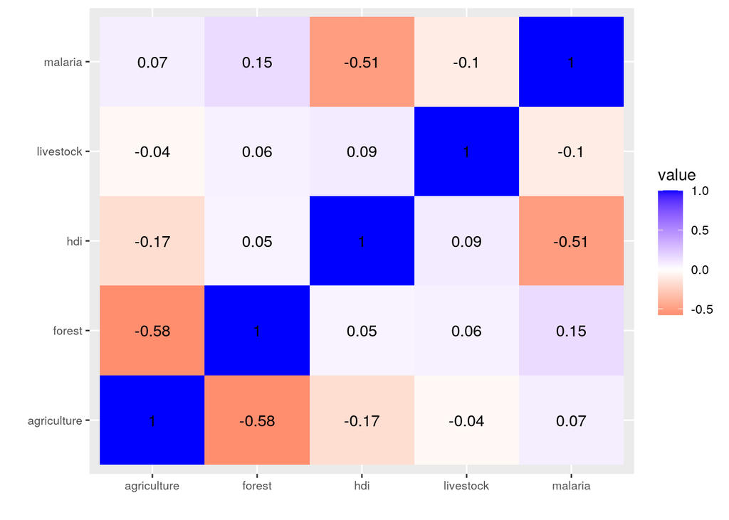

```r
library(cluster)
library(ggplot2)

# clustering code here and in the following code chunk
corr_matrix <- avg_final_data %>% select(-country) %>% cor(use = "pair")
corr_matrix %>% as.data.frame %>% rownames_to_column %>% pivot_longer(-1) %>%
    ggplot(aes(rowname, name, fill = value)) + geom_tile() +
    geom_text(aes(label = round(value, 2))) + xlab("") + ylab("") +
    scale_fill_gradient2(low = "red", mid = "white", high = "blue") +
    theme(axis.text = element_text(size = 8))
```

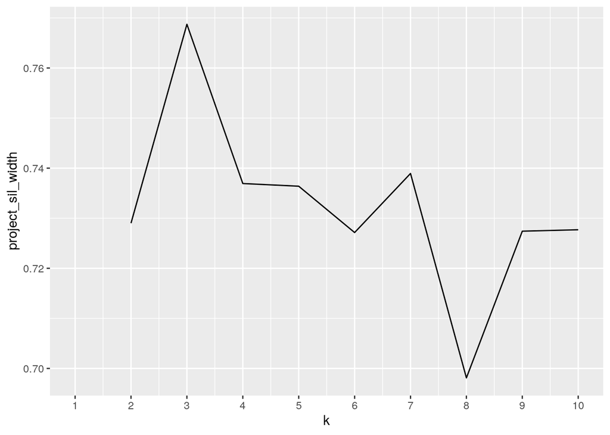

```r
# Choosing the number of clusters that maximizes average
# silhouette width
pam_data <- avg_final_data %>% select(-country)
project_sil_width <- vector()
for (i in 2:10) {
    project_pam_fit <- pam(pam_data, k = i)
    project_sil_width[i] <- project_pam_fit$silinfo$avg.width
}

ggplot() + geom_line(aes(x = 1:10, y = project_sil_width)) +
    scale_x_continuous(name = "k", breaks = 1:10)
```

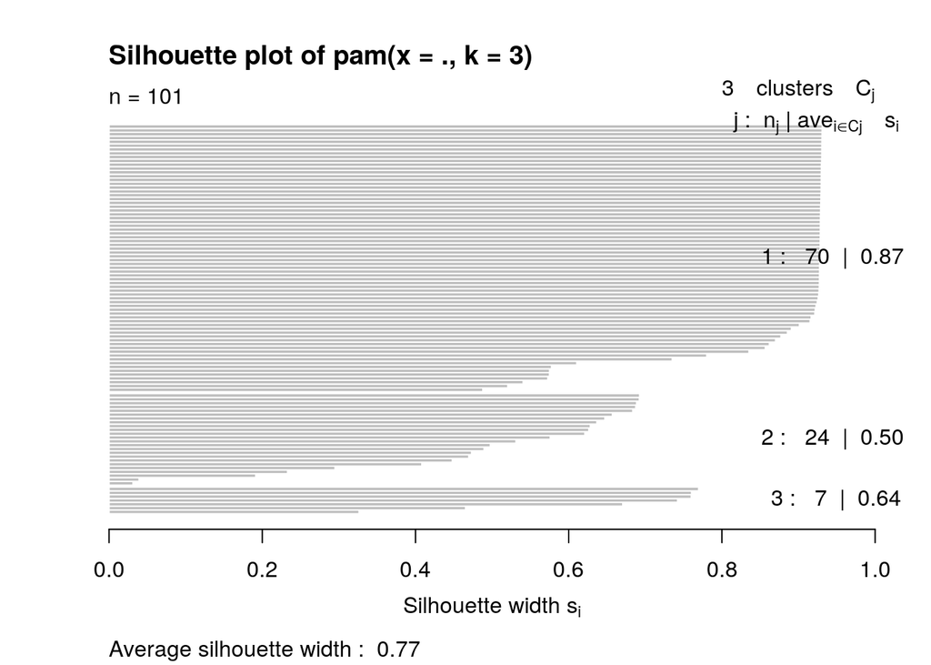

```r
# run PAM
project_pam <- pam_data %>% pam(k = 3)

# how good is cluster solution
plot(project_pam, which = 2)
```

```r
project_pam$silinfo$avg.width
```

```
## [1] 0.7687281
```

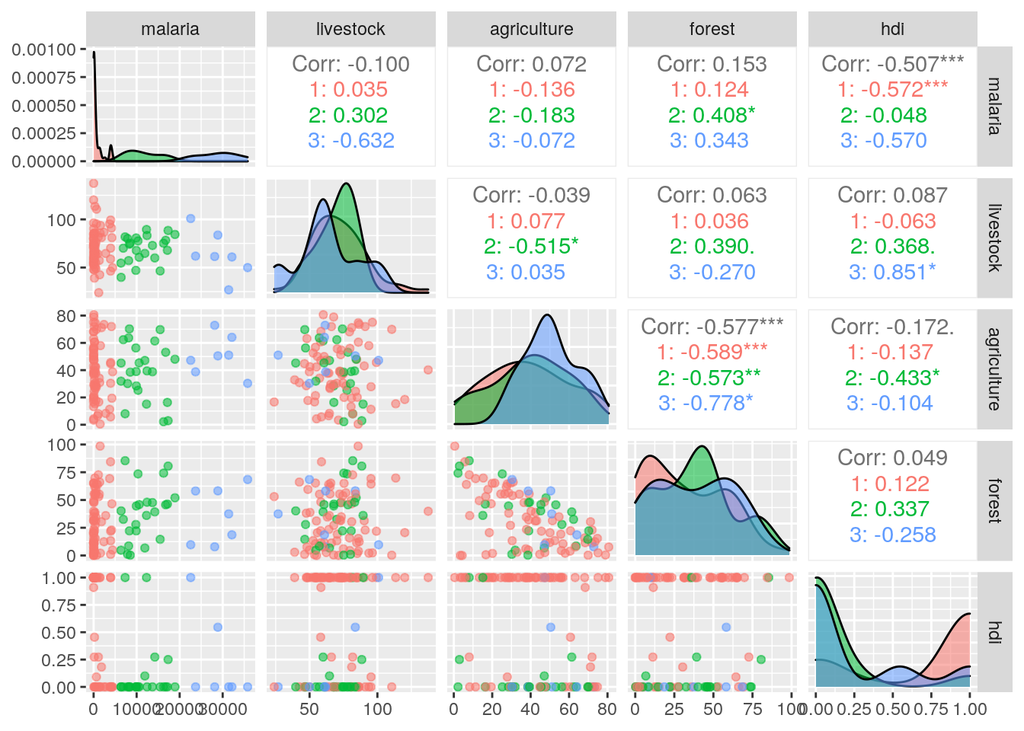

```r
# visualizing the clusters
library(GGally)
project_pairwise <- avg_final_data %>% mutate(cluster = as.factor(project_pam$clustering))

ggpairs(project_pairwise, columns = 2:6, aes(color = cluster,
    alpha = 0.7))
```

I used a for-loop to decide how many clusters to pick based on the largest average silhouette width. The silhouette widths were plotted for when k was equal to 2 through 10 using ggplot, and k=3 (3 clusters) had the highest average silhouette width. At k=3, the clusters are both the most cohesive and separated. The average silhouette width is 0.769, which indicates that there is a “strong structure,” so the cluster solution is good.

The pairwise plots are pretty similar. However, the red cluster is very separated from the green and blue clusters in the HDI plot. This indicates that most of the countries over the 11 year period either remained an LDC or remained an MDC. Very few countries changed their status (either from LDC to MDC or vice versa). The greatest negative correlation (-0.577) is between the percent of land covered in forest and the percent of land used for agriculture. Additionally, there is a negative correlation (-0.507) between HDI and the number of malaria cases (per 100,000 people). This could indicate a couple patterns. Countries that have low HDI scores might happen to be located where malaria is most common (around the equator), and/or countries that have low HDI scores might not have their malaria cases as well under control as countries with high HDI scores. The variables with the strongest positive correlation are “forest” and “malaria;” however, the correlation is pretty weak overall (0.153). The variables that show the least correlation are “agriculture” and “livestock” (-0.039), which is interesting since these variables are both related to agricultural production. Based on the cluster scatterplots, the countries in the red cluster tend to have slightly higher HDI scores overall and very low rates of malaria incidence, the countries in the green cluster tend to have low HDI scores with moderates rates of malaria incidence, and the countries in the blue cluster have low HDI scores with the highest rates of malaria incidence. There do not appear to be other noteworthy trends. However, I think it is interesting that in the density plots, the countries in the red cluster (higher HDI scores) had slightly less land covered in forest, and countries in the blue cluster (low HDI scores) had slightly more land used for agriculture. I think that one reason why the countries with higher HDI scores might have less forest cover is they could be more urbanized than countries with low HDI scores. Additionally, one potential reason why countries with low HDI scores have more land used for agriculture is their economies might be agriculture-based, whereas countries with higher HDI scores are more likely to have industry and service-based economies.

### Dimensionality Reduction with PCA

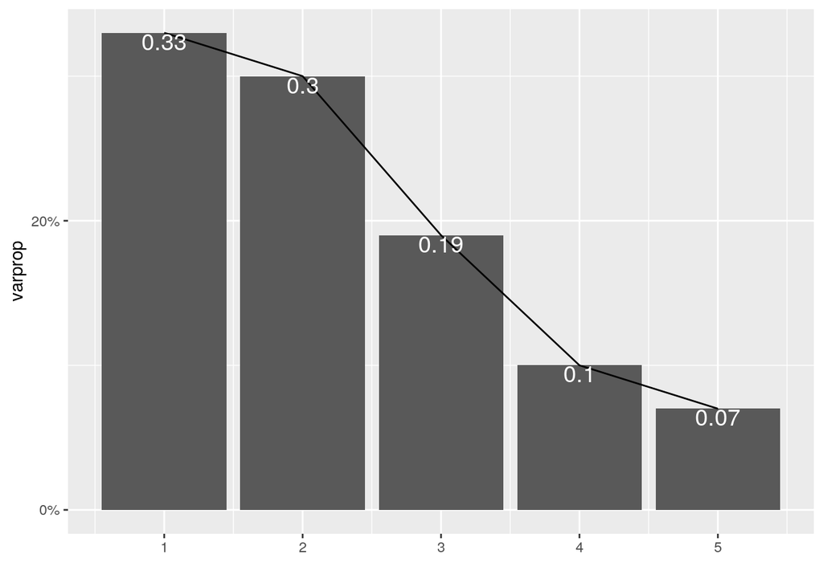

```r
# PCA code here
library(ggplot2)
project_nums <- avg_final_data %>% select_if(is.numeric) %>%
    scale
rownames(project_nums) <- avg_final_data$country
project_pca <- princomp(project_nums, cor = T)

eigval_project <- project_pca$sdev^2
varprop = round(eigval_project/sum(eigval_project), 2)

# scree plot
ggplot() + geom_bar(aes(y = varprop, x = 1:5), stat = "identity") +
    xlab("") + geom_path(aes(y = varprop, x = 1:5)) + geom_text(aes(x = 1:5,
    y = varprop, label = round(varprop, 2)), vjust = 1, col = "white",
    size = 5) + scale_y_continuous(breaks = seq(0, 0.6, 0.2),
    labels = scales::percent) + scale_x_continuous(breaks = 1:10)
```

```r
# cumulative proportion of variance
round(cumsum(eigval_project)/sum(eigval_project), 2)
```

```
## Comp.1 Comp.2 Comp.3 Comp.4 Comp.5
##   0.33   0.63   0.83   0.93   1.00
```

```r
# eigenvalues (Kaiser's rule)
eigval_project
```

```
##    Comp.1    Comp.2    Comp.3    Comp.4    Comp.5
## 1.6668293 1.4996681 0.9688348 0.4956140 0.3690538
```

```r
summary(project_pca, loadings = T)
```

```
## Importance of components:
##                           Comp.1    Comp.2    Comp.3     Comp.4     Comp.5
## Standard deviation     1.2910574 1.2246094 0.9842941 0.70399861 0.60749799
## Proportion of Variance 0.3333659 0.2999336 0.1937670 0.09912281 0.07381076
## Cumulative Proportion  0.3333659 0.6332995 0.8270664 0.92618924 1.00000000
##
## Loadings:
##             Comp.1 Comp.2 Comp.3 Comp.4 Comp.5
## malaria      0.346  0.614  0.114  0.571  0.405
## livestock   -0.197 -0.112  0.972
## agriculture  0.603 -0.340  0.123  0.395 -0.592
## forest      -0.496  0.520         0.211 -0.662
## hdi         -0.481 -0.474 -0.165  0.688  0.207
```

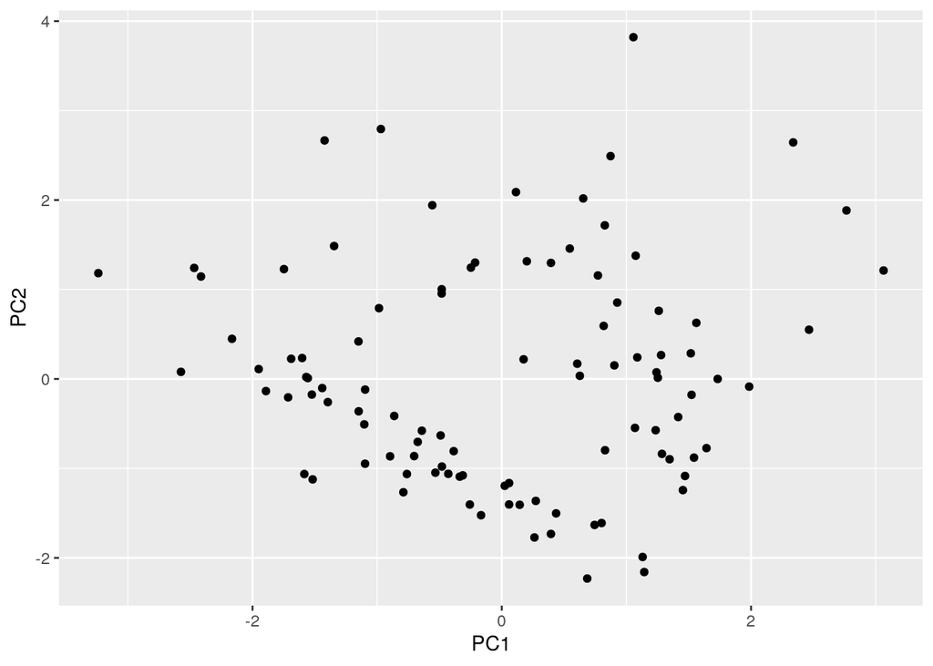

```r
pca_df <- data.frame(HDI = avg_final_data$hdi, PC1 = project_pca$scores[,
    1], PC2 = project_pca$scores[, 2], PC3 = project_pca$scores[,
    3])

ggplot(data = pca_df, aes(x = PC1, y = PC2)) + geom_point()
```

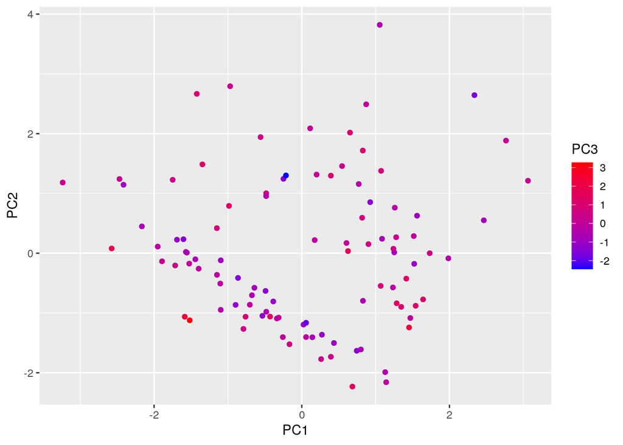

```r
# color PC3
ggplot(data = pca_df, aes(x = PC1, y = PC2)) + geom_point(aes(color = PC3)) +
    scale_color_gradient(low = "blue", high = "red")
```

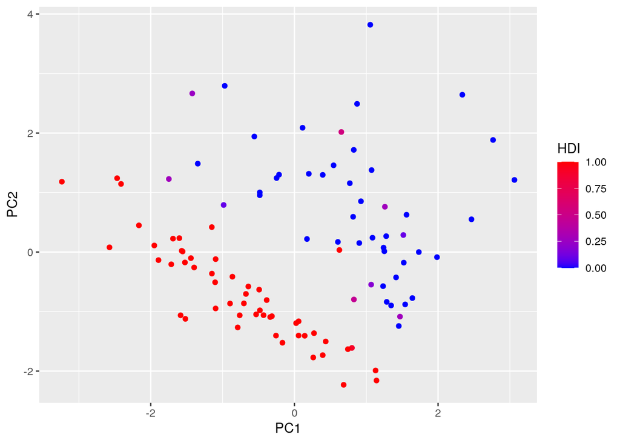

```r
# color HDI
ggplot(data = pca_df, aes(x = PC1, y = PC2)) + geom_point(aes(color = HDI)) +
    scale_color_gradient(low = "blue", high = "red")
```

I made a scree plot, found the cumulative proportion of variance for the PCs, and analyzed the eigenvalues to determine how many PCs to keep. Since the cumulative proportion of variance reaches above 80% at Comp. 3 (0.83), it is probably best to keep 3 PCs.

PC1 represents Agriculture versus Forest Cover and HDI. Countries that have a higher percent of land for agriculture have lower HDI scores and have a lower percent of land covered in forest. Countries with a low percent of land for agriculture have higher HDI scores and a higher percent of land covered in forest. PC2 represents Malaria Incidence versus HDI. Countries with a high incidence of malaria tend to have lower HDI scores, and countries with a low incidence of malaria tend to have higher HDI scores. PC3 represents Livestock versus HDI. Countries with higher livestock production index scores tend to have lower HDI scores, and countries with lower livestock production index scores tend to have higher HDI scores. 82.71% of the total variance in the dataset is explained by PC1, PC2, and PC3. I think it makes sense that countries with lower HDI scores tend to have relatively more land devoted to agriculture (PC1) and also have higher livestock production index scores (PC3) since these countries are more likely to have agriculture-based economies. Additionally, since countries with higher HDI scores probably have more access to medical resources, it is makes sense that these countries also have lower rates of malaria incidence (PC2).

### Linear Classifier

```r
# linear classifier code here
LC_data <- avg_final_data %>% mutate(avg_HDI = ifelse(hdi > 0.5,
    1, 0)) %>% select(-hdi)

project_fit <- glm(avg_HDI == "1" ~ malaria + livestock + forest +
    agriculture, data = LC_data, family = "binomial")

prob_project <- predict(project_fit, type = "response")
class_diag(prob_project, LC_data$avg_HDI, positive = "1")
```

```
##           acc   sens   spec    ppv     f1     ba    auc
## Metrics 0.802 0.9434 0.6458 0.7463 0.8333 0.7946 0.8479
```

```r
# confusion matrix
table(truth = LC_data$avg_HDI == 1, prediction = prob_project >
    0.5)
```

```
##        prediction
## truth   FALSE TRUE
##   FALSE    31   17
##   TRUE      3   50
```

```r
# cross-validation of linear classifier here
library(caret)
set.seed(1234)

# choosing the number of folds
k = 10

data <- LC_data[sample(nrow(LC_data)), ] %>% select(-country)
folds <- cut(seq(1:nrow(LC_data)), breaks = k, labels = F)

diags <- NULL
for (i in 1:k) {
    # Creating training and test sets
    train <- data[folds != i, ]
    test <- data[folds == i, ]
    truth <- test$avg_HDI
    # Training model on training set
    fit <- glm(avg_HDI ~ forest + agriculture + malaria + livestock,
        data = train, family = "binomial")
    # Testing model on test set (save all k results)
    probs <- predict(fit, newdata = test, type = "response")
    # Get diagnostics
    diags <- rbind(diags, class_diag(probs, truth, positive = 1))
}

# average diagnostics across all k folds
summarize_all(diags, mean)
```

```
##       acc    sens   spec     ppv      f1      ba     auc
## 1 0.78182 0.91667 0.6269 0.72758 0.79835 0.77179 0.81299
```

When I used logistic regression to predict the binary variable (HDI) from all of my numeric variables (malaria, livestock, forest, and agriculture) the AUC was 0.8479, which indicates that the model is doing pretty good. When I performed a k-fold CV, the CV AUC was 0.8130, which indicates the model is doing okay but not as well. The model did not predict new observations as well as indicated by the decrease in the CV AUC. Since the AUC dropped in the CV, this indicates that there is likely overfitting. I think that is order to say that the model is doing “great” the AUC would need to be at least 0.90.

### Non-Parametric Classifier

```r
# non-parametric classifier code here
library(caret)
knn_fit <- knn3(avg_HDI == "1" ~ malaria + livestock + agriculture +
    forest, data = LC_data)

prob_knn <- predict(knn_fit, LC_data)[, 2]
class_diag(prob_knn, LC_data$avg_HDI, positive = "1")
```

```
##            acc   sens   spec    ppv     f1     ba   auc
## Metrics 0.8515 0.8113 0.8958 0.8958 0.8515 0.8536 0.922
```

```r
## confusion matrix
table(truth = LC_data$avg_HDI == 1, prediction = prob_knn > 0.5)
```

```
##        prediction
## truth   FALSE TRUE
##   FALSE    43    5
##   TRUE     10   43
```

```r
# cross-validation of np classifier here
set.seed(1234)

k = 10

data <- LC_data[sample(nrow(LC_data)), ]
folds <- cut(seq(1:nrow(LC_data)), breaks = k, labels = F)

diags <- NULL

for (i in 1:k) {
    # Create training and test sets
    train <- data[folds != i, ]
    test <- data[folds == i, ]
    truth <- test$avg_HDI
    # Train model on training set
    fit <- knn3(avg_HDI ~ malaria + livestock + agriculture +
        forest, data = train)
    # Test model on test set (save all k results)
    probs <- predict(fit, newdata = test)[, 2]
    # Get diagnostics
    diags <- rbind(diags, class_diag(probs, truth, positive = 1))
}

summarize_all(diags, mean)
```

```
##       acc    sens    spec    ppv      f1      ba     auc
## 1 0.81182 0.81072 0.80381 0.8342 0.80381 0.80725 0.83938
```

When I used k-nearest neighbors to predict the binary variable (HDI) from all of my numeric variables (malaria, livestock, forest, and agriculture) the AUC was 0.922, which indicates that the model is doing very well. When I performed a k-fold CV, the CV AUC was 0.8394, which indicates that the model is doing pretty good but not as well. The model did not predict new observations as well as indicated by the decrease in the CV AUC. Since the AUC dropped in the CV, this indicates that there is likely overfitting. Compared to the linear model, the nonparametric model is doing better in terms of its cross-validation performance. Since the nonparametric model’s CV AUC (0.8394) is higher than the linear model’s CV AUC (0.8130), this indicates that the CV performance for the nonparametric model is better.

### Regression/Numeric Prediction

```r
# regression model code here
reg_data <- avg_final_data %>% select(-country)
fit <- lm(agriculture ~ ., data = reg_data)
yhat <- predict(fit)

# MSE
mean((reg_data$agriculture - yhat)^2)
```

```
## [1] 270.4508
```

```r
# cross-validation of regression model here
set.seed(1234)

k = 10

# randomly order rows
data <- reg_data[sample(nrow(reg_data)), ]
# create folds
folds <- cut(seq(1:nrow(reg_data)), breaks = k, labels = F)

diags <- NULL
for (i in 1:k) {
    train <- data[folds != i, ]
    test <- data[folds == i, ]
    # Fit linear regression model to training set
    fit <- lm(agriculture ~ ., data = train)
    # Get predictions/y-hats on test set (fold i)
    yhat <- predict(fit, newdata = test)
    # Compute prediction error (MSE) for fold i
    diags <- mean((test$agriculture - yhat)^2)
}

# average MSE across all folds
mean(diags)
```

```
## [1] 287.0851
```

The MSE for the overall dataset is 270.4508, which is very high. The average MSE across the k testing folds was 287.0851, which is even higher and indicates that there is overfitting. (Since the MSE is higher in the CV, this indicates that there is likely overfitting.)

### Python

```r
# R code chunk
library(reticulate)
use_python("/usr/bin/python3", required = F)

pathogen <- "Plasmodium"
```

```python
# python code here
pathogen= "knowlesi"
print(r.pathogen, pathogen)
```

```
## Plasmodium knowlesi
```

```r
# R code chunk
cat(c(pathogen, py$pathogen))
```

```
## Plasmodium knowlesi
```

In the python code chunk, I created an object called “pathogen” that prints “knowlesi,” and in the R code chunk, I created another object called “pathogen” that prints “Plasmodium.” Reticulate was used to share the objects between R and python. In the python code chunk, “r.pathogen” shared the R object with python, and in the R code chunk, “py$pathogen” was used to share the python object with R. Lastly, “print” and “cat” were used to concatenate the words into the name “Plasmodium knowlesi.” Plasmodium knowlesi is a species of malaria parasite that is unique because it is zoonotic (i.e. it can be transmitted between animals and humans).

### Concluding Remarks

In this project, it was interesting to compare the CV AUCs of the different types of models and to determine which kind of model fit the data best. In future studies, it could be useful to compare the livestock, forest, and agriculture data to the incidence of zoonotic infectious diseases, such as Nipah and SARS-CoV-2 because these pathogens have well-documented relationships with agricultural expansion and deforestation. Additionally, many noteworthy zoonoses (Ebola, SARS, SARS-CoV-2, Hendra, Nipah, MERS, etc.) likely use bats as reservoir hosts. Therefore, it could be valuable to conduct the above analyses with data that the included information on the a) distribution of these bat species and b) percent of land that serves as suitable bat habitat. I am curious to know how these variables change over time. Also, it could be interesting to see how well these data can be used to predict the incidence of zoonoses. These models might have useful applications for predicting where future outbreaks of zoonoses are most likely to occur.